# **Analysis of Heart Disease Mortality Data**

#### **Analysis of Graphs of Anxiety Disorder Prevalence Distribution Over Years**

Below, we have plotted a box and violin plot for the % of population with anxiety disorders distribution (anxiety disorder prevalence) per year from 2012-2017, two line graphs of mean and standard deviation for % of population with anxiety disorders from 2012-2017, and summary statistics. Based on the violin plot, we can tell that the % of population with anxiety disorder distributions are all unimodal, relatively identical, uniform, and mostly normal, which means the mean and median smoking percentages in each year are extremely close. The box plot also show that there are mainly upper outliers within the % of population with anxiety disorders distributions. The line graphs indicate that the mean of anxiety disorder prevalence increases while the standard deviation decreases over time (from 2012-2017), which means the center of the anxiety disorder prevalence distribution increases while the spread decreases. For the % of population with anxiety disorders data overall across all countries from 2012-2017, the mean anxiety disorder prevalence is 4.14% with a standard devation of 1.04% and median of 4%. Given all this evidence, the primary conclusion we can draw about the % of population with anxiety disorders feature is that it increases with similar distributions, making it likely a major and constant risk factor in heart disease mortality rate predictions. It can be considered a reliable feature in analysis, hypothesis testing & ML due to the lower bias.

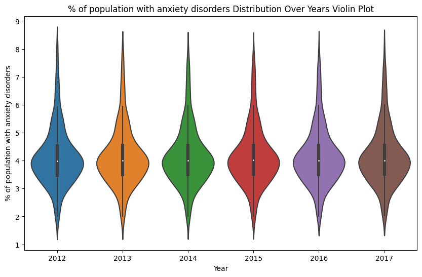

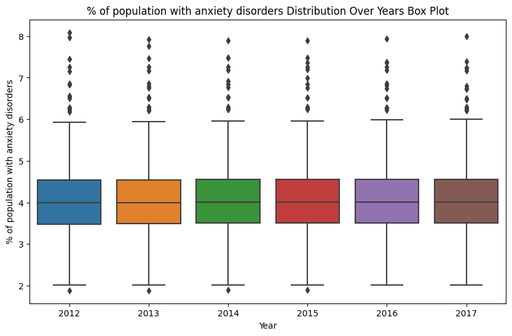

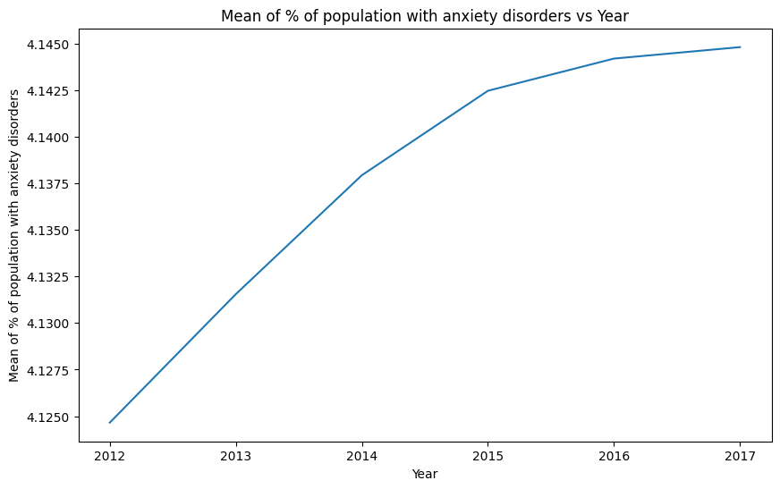

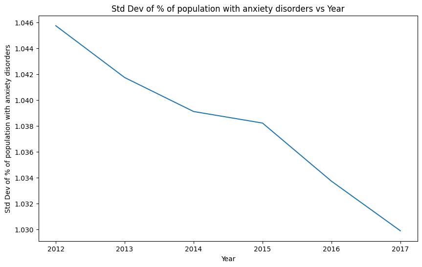

```
count    1368.000000
mean        4.137595
std         1.036205
min         1.884744
25%         3.495483
50%         4.001340
75%         4.546199
max         8.088891
Name: % of population with anxiety disorders, dtype: float64
```

```python
graph_feature('% of population with anxiety disorders')
```